# DATA 605 FUNDAMENTALS OF COMPUTATIONAL MATHEMATICS

Assignment 15: Calculus Week 3

Kyle Gilde

12/6/2017

1. Find the equation of the regression line for the given points. Round any final values to the nearest hundredth, if necessary. ( 5.6, 8.8 ), ( 6.3, 12.4 ), ( 7, 14.8 ), ( 7.7, 18.2 ), ( 8.4, 20.8 )

```r
given_points <- c(5.6, 8.8, 6.3, 12.4, 7, 14.8, 7.7, 18.2, 8.4, 20.8)
D <- matrix(given_points, ncol = 2, byrow = TRUE)

df <- data.frame(D)
names(df) <- c("x", "y")

the_model <- lm(y ~ x, df)

b <- the_model$coefficients[1]
m <- the_model$coefficients[2]

paste0("y = ", round(m, 2), "x + ", b)
```

```
## [1] "y = 4.26x + -14.8"
```

2. Find all local maxima, local minima, and saddle points for the function given below. Write your answer(s) in the form ( x, y, z ). Separate multiple points with a comma.

$f ( x, y ) = 24x - 6xy^2 - 8y^3$

```r
interval <- 10000

fxy <- function(x, y) {
    24 * x - 6 * x * y^2 - 8 * y^3
}
(fxy_prime <- Deriv(fxy))
```

```
## function (x, y)
## c(x = 24 - 6 * y^2, y = -(y * (12 * x + 24 * y)))
```

```r
# f_x critical points
f_x <- function(y) 24 - 6 * y^2
f_x_critical_points <- uniroot.all(f_x, c(-interval, interval))

# f_y critical points
f_y_critical_points <- c(NA, NA)
f_y <- function(x, y) -12 * x * y - 24 * y^2
f_y_critical_points[1] <- uniroot.all(f_y, c(-interval, interval), y = f_x_critical_points[1])
f_y_critical_points[2] <- uniroot.all(f_y, c(-interval, interval), y = f_x_critical_points[2])

(critical_points <- expand.grid(f_x_critical_points, f_y_critical_points))
```

```
##        Var1     Var2
## 1 -1.999975  3.99995
## 2  1.999975  3.99995
## 3 -1.999975 -3.99995
## 4  1.999975 -3.99995
```

```r
# 2nd partial derivatives
(fxy_dblprime <- Deriv(fxy_prime))
```

```
## function (x, y)
## {
##     .e1 <- -(12 * y)
##     c(x = c(x = 0, y = .e1), y = c(x = .e1, y = -(12 * x + 48 *
##         y)))
## }
```

```r
f_xx <- function(x, y) 0
f_xy <- function(x, y) -(12 * y)
f_yy <- function(x, y) -(12 * x + 48 * y)
f_yx <- function(x, y) -(12 * y)

D <- function(x, y) f_xx(x, y) * f_yy(x, y) - f_xy(x, y) * f_yx(x, y)

assess_points <- function(critical_points) {
    r <- nrow(critical_points)
    for (i in 1:r) {
        D_result <- round(D(critical_points[i, 1], critical_points[i, 2]), 4)
        z <- fxy(critical_points[i, 1], critical_points[i, 2])
        point <- paste(round(c(critical_points[i, 1], critical_points[i, 2],
            z), 4), collapse = " ")

        if (D_result == 0) {
            conclusion <- paste0(point, "; D = ", D_result, " ;Inconclusive")
        } else if (D_result < 0) {
            conclusion <- paste0(point, "; D = ", D_result, " ;Saddle Point")
        } else {
            f_xx_result <- f_xx(critical_points[i, 1], critical_points[i, 2])
            if (f_xx_result > 0) {
                paste0(point, "; D = ", D_result, " ;f_xx > 0; ", "Local Minimum")
            } else if (f_xx_result < 0) {
                conclusion <- paste0(point, "; D = ", D_result, " ;f_xx < 0; ",
                  "Local Maximum")
            }
        }
        print(conclusion)
    }
}
assess_points(critical_points)
```

```
## [1] "-2 3.9999 -367.9873; D = -2303.9419 ;Saddle Point"
## [1] "2 3.9999 -655.974; D = -2303.9419 ;Saddle Point"
## [1] "-2 -3.9999 655.974; D = -2303.9419 ;Saddle Point"
## [1] "2 -3.9999 367.9873; D = -2303.9419 ;Saddle Point"
```

3. A grocery store sells two brands of a product, the “house” brand and a “name” brand. The manager estimates that if she sells the “house” brand for x dollars and the “name” brand for y dollars, she will be able to sell $81 - 21x + 17y$ units of the “house” brand and $40 + 11x - 23y$ units of the “name” brand.

Step 1. Find the revenue function R ( x, y ).

$R (x, y) = x(81 - 21x + 17y) + y(40 + 11x - 23y)$

$R (x, y) = -21x^2 + 81x + 28xy + 40y - 23y^2$

Step 2. What is the revenue if she sells the “house” brand for $2.30 and the “name” brand for $4.10?

```r
x <- 2.3
y <- 4.1
fxy <- function(x, y) -21 * x^2 + 81 * x + 28 * x * y + 40 * y - 23 * y^2

fxy(x, y)
```

```
## [1] 116.62
```

4. A company has a plant in Los Angeles and a plant in Denver. The firm is committed to produce a total of 96 units of a product each week. The total weekly cost is given by $C(x, y) = 1/6x^2 + 1/6y^2 + 7x + 25y + 700$, where x is the number of units produced in Los Angeles and y is the number of units produced in Denver. How many units should be produced in each plant to minimize the total weekly cost?

$96 = x + y \rightarrow y = 96 - x$

$1/6x^2 + 1/6y^2 + 7x + 25y + 700 \rightarrow 1/6x^2 + 1/6(96 - x)^2 + 7x + 25(96 - x) + 700$

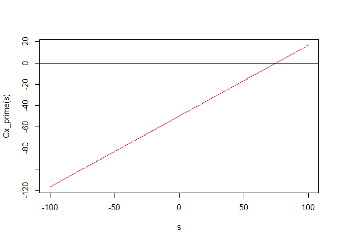

```r
Cx <- function(x) 1/6 * x^2 + 1/6 * (96 - x)^2 + 7 * x + 25 * (96 - x) + 700
Cx_prime <- Deriv(Cx)

s <- seq(-100, 100, by = 1)
plot(s, Cx_prime(s), type = "l", col = "red")
abline(0, 0)
```

```r
(x <- uniroot(Cx_prime, c(-100, 100))$root)
```

```
## [1] 75
```

```r
(y <- 96 - x)
```

```
## [1] 21
```

5. Evaluate the double integral on the given region. Write your answer in exact form without decimals

$\iint(e^{8x + 3y }dA)$

$R: 2 \leq x \leq 4$

and

$2\leq y \leq 4$

$$\begin{equation}
\iint(e^{8x + 3y} dA) = \int_{2}^{4}\int_{2}^{4}e^{8x + 3y} dydx
\end{equation}$$
$$\begin{equation}
= \int_{2}^{4}\left(\left[1/3e^{8x + 3y}|_2^4 \right]\right)dx
\end{equation}$$
$$\begin{equation}
= \int_{2}^{4}\left( 1/3(e^{8x + 12} - e^{8x + 6}) \right)dx
\end{equation}$$
$$\begin{equation}
= \left( 1/24(e^{8x + 12} - e^{8x + 6})\right)|_{2}^{4}
\end{equation}$$
$$\begin{equation}
= 1/24\left(e^{44} - e^{38} - e^{28} + e^{22}\right)
\end{equation}$$